# Assignment 1

Srecko Curkovic

12/7/2020

In this assignment, we create two line charts showing monthly total electricity and gas consumption (in the units of kBTUs) for the 9 Bay Area counties. The time frame is from January 2017 to September 2020, the latest available month in the PG&E data set. One chart shows residential consumption and another one shows commercial consumption.

We start with the initial knitting set-up. We want to show all code on the web report and we want to run it, but we do not want to show warnings and messages. We also want to show the final plots as outputs.

```r
knitr :: opts_chunk$set(include=T, echo=T, warning=F, message=F, eval=T)
```

We then load all the libraries necessary for this assignment.

```r
library(tidyverse)
library(plotly)
library(sf)
library(tigris)
library(leaflet)
library(data.table)
```

We want to do our analysis just for the Bay Area counties. So the first step is to get a list of the Bay Area ZIP codes. We create a list of the Bay Area counties and then use that to filter the list of all the ZIP codes in the country.

```r
bay_county_names <- c("Alameda", "Contra Costa", "Marin", "Napa", "San Francisco",
                      "San Mateo", "Santa Clara", "Solano", "Sonoma")

bay_counties <- counties("CA", cb=T, progress_bar=F) %>% filter(NAME %in% bay_county_names)

usa_zips <- zctas(cb=T, progress_bar=F)

bay_zips <- usa_zips %>% st_centroid() %>% .[bay_counties, ] %>%
  st_set_geometry(NULL) %>% left_join(usa_zips %>% select(GEOID10)) %>% st_as_sf()
```

PG&E provides the consumption data on a quarterly basis. So the next step is to load the individual quarter data sets and merge them into two larger data sets: one for electricity and one for gas. We use nested for loops for this.

```r
type1 <- "Electric"
type2 <- "Gas"

pge_4yrs_elec <- NULL
pge_4yrs_gas <- NULL

for(year in c(2017, 2018, 2019, 2020)) {
  for(quarter in 1:4) {

    if(year==2020 && quarter==4) {
        break
    }

    filename1 <- paste0("PGE_", year, "_Q", quarter, "_", type1, "UsageByZip.csv")
    temp1 <- read_csv(filename1)
    pge_4yrs_elec <- rbind(pge_4yrs_elec, temp1)

    filename2 <- paste0("PGE_", year, "_Q", quarter, "_", type2, "UsageByZip.csv")
    temp2 <- read_csv(filename2)
    pge_4yrs_gas <- rbind(pge_4yrs_gas, temp2)
  }
}
```

Now we filter the two data sets to keep just the residential and commercial consumption, just the relevant columns, and just the data for the Bay Area. Here we make use of the list of the Bay Area ZIP codes.

```r
pge_4yrs_elec_filter <- filter(pge_4yrs_elec, CUSTOMERCLASS %in%
                                 c("Elec- Residential", "Elec- Commercial"))

pge_4yrs_gas_filter <- filter(pge_4yrs_gas, CUSTOMERCLASS %in%
                                 c("Gas- Residential", "Gas- Commercial"))

pge_4yrs_elec_select <- select(pge_4yrs_elec_filter, !c(COMBINED, AVERAGEKWH))
pge_4yrs_gas_select <- select(pge_4yrs_gas_filter, !c(COMBINED, AVERAGETHM))

pge_4yrs_elec_bay <- filter(pge_4yrs_elec_select, ZIPCODE %in% bay_zips$ZCTA5CE10)
pge_4yrs_gas_bay <- filter(pge_4yrs_gas_select, ZIPCODE %in% bay_zips$ZCTA5CE10)
```

Next we group and summarize the data for total kWh and total thm. We also sort the data in increasing order of year and month.

```r
pge_4yrs_elec_bay_group <- group_by(pge_4yrs_elec_bay, MONTH, YEAR, CUSTOMERCLASS)
pge_4yrs_gas_bay_group <- group_by(pge_4yrs_gas_bay, MONTH, YEAR, CUSTOMERCLASS)

pge_4yrs_elec_bay_sum <- summarize(pge_4yrs_elec_bay_group, TOTALKWH=sum(TOTALKWH, na.rm=T))
pge_4yrs_gas_bay_sum <- summarize(pge_4yrs_gas_bay_group, TOTALTHM=sum(TOTALTHM, na.rm=T))

pge_4yrs_elec_bay_sum_sort <- pge_4yrs_elec_bay_sum[
  order(pge_4yrs_elec_bay_sum$YEAR, pge_4yrs_elec_bay_sum$MONTH), ]

pge_4yrs_gas_bay_sum_sort <- pge_4yrs_gas_bay_sum[
  order(pge_4yrs_gas_bay_sum$YEAR, pge_4yrs_gas_bay_sum$MONTH), ]
```

We now merge the two data sets and we also convert both kWh and thm to kBTU using the following conversions found online:

1 kWh = 3.412 kBTU; 1 thm = 100.00000947817 kBTU

```r
pge_final <- pge_4yrs_elec_bay_sum_sort
pge_final$TOTALTHM <- pge_4yrs_gas_bay_sum_sort$TOTALTHM

pge_final$KBTU_ELEC <- pge_final$TOTALKWH * 3.412
pge_final$KBTU_GAS <- pge_final$TOTALTHM * 100.00000947817
```

In the next step, we split the previous data set into two new data sets: one for residential consumption and one for commercial consumption.

```r
pge_res <- filter(pge_final, CUSTOMERCLASS %in% c("Elec- Residential", "Gas- Residential"))
pge_comm <- filter(pge_final, CUSTOMERCLASS %in% c("Elec- Commercial", "Gas- Commercial"))

pge_res$CUSTOMERCLASS <- "Residential"
pge_comm$CUSTOMERCLASS <- "Commercial"
```

Now we finally have two data sets that are ready for plotting. We create two separate line charts, one for each data set.

```r
pge_chart_res <-
  pge_res %>%
  ggplot() +
  geom_line(aes(x=1:45, y=KBTU_ELEC, color="darkred")) +
  geom_line(aes(x=1:45, y=KBTU_GAS, color="darkblue")) +
  labs(x="Month", y="kBTU", title="PG&E Monthly Residential Electricity & Gas Usage
       in the Bay Area, 2017-2020") +
  scale_colour_manual(name="Type", values=c("darkred"="darkred", "darkblue"="darkblue"),
                      labels = c("Electricity", "Gas"))

pge_chart_comm <-
  pge_comm %>%
  ggplot() +
  geom_line(aes(x=1:45, y=KBTU_ELEC, color="darkred")) +
  geom_line(aes(x=1:45, y=KBTU_GAS, color="darkblue")) +
  labs(x="Month", y="kBTU", title="PG&E Monthly Commercial Electricity & Gas Usage
       in the Bay Area, 2017-2020") +
  scale_colour_manual(name="Type", values=c("darkred"="darkred","darkblue"="darkblue"),
                      labels = c("Electricity", "Gas"))
```

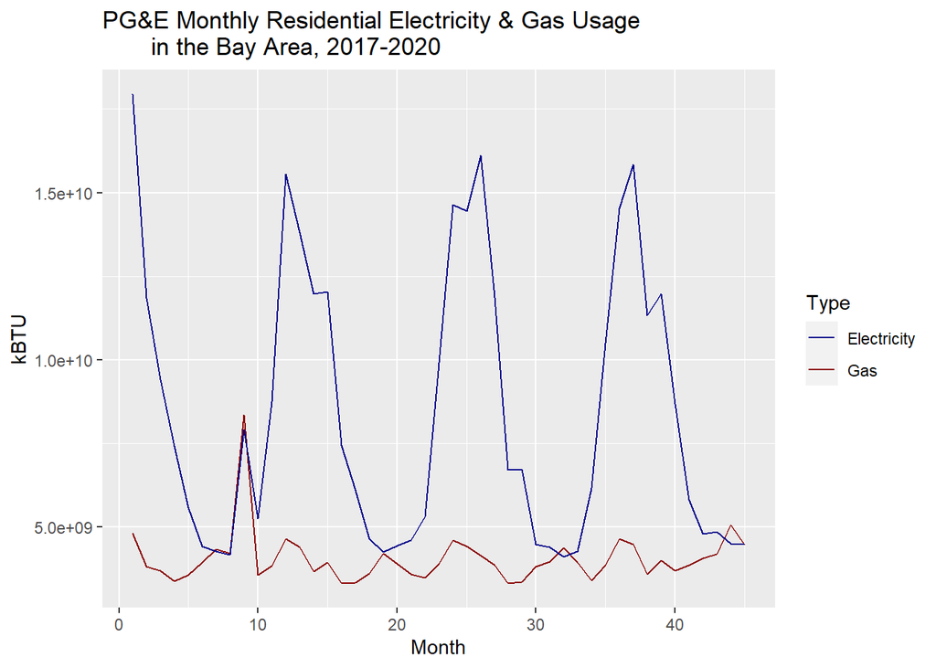

```r
pge_chart_res
```

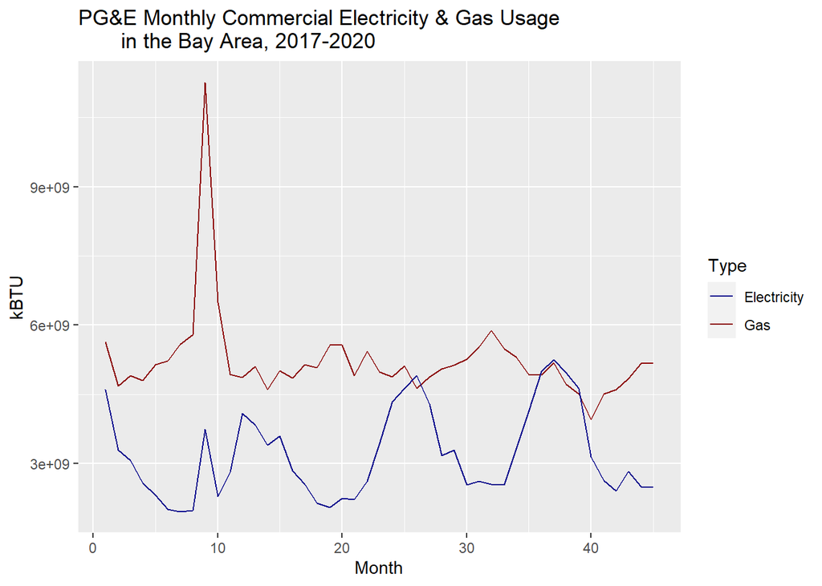

```r
pge_chart_comm
```

The numbers on the x-axis stand for months: 1 is January 2017, 2 is February 2017, and so on until September 2020 (45).

The first thing we can notice from both plots is that the data for September 2017 is unusually high, i.e. there is a peak on all the lines for this month, not seen for September of the following years. For the gas consumption in both plots, this peak is significantly higher than any other month. For example, for the commercial gas consumption, this value is almost double the value of the next highest consumption. Since there is no obvious reason for these values to be so unusually high, it is likely that a measurement error by PG&E occurred. Thus, the data for this month should be adjusted.

The final part of this assignment is creating a map that shows which neighborhoods in the Bay Area experienced the greatest change in the electricity consumption before and after the pandemic began. We are going to look only at the residential electricity consumption comparison between July 2019 and July 2020. These two months were selected because of the difference in values that can be seen on the total residential electricity and gas consumption plot above. The neighborhoods are represented as ZCTAs.

```r
usa_zips <-
  zctas(cb = T, progress_bar = F)

bay_zips <-
  usa_zips %>%
  st_centroid() %>%
  .[bay_counties, ] %>%
  st_set_geometry(NULL) %>%
  left_join(usa_zips %>% select(GEOID10)) %>%
  st_as_sf()
```

We create two datasets (one for July 2019 and one for July 2020) that show the electricity consumption by ZIP codes. Then, we convert kWh to kBTU in the same way as before, we merge the two data sets by ZIP codes, and we calculate the percentage difference in residential electricity consumption for each ZIP code.

```r
elec_jul_19 <-
  pge_4yrs_elec_bay %>%
  filter(CUSTOMERCLASS == "Elec- Residential") %>%
  filter(YEAR %in% c(2019), MONTH %in% c(7)) %>%
  mutate(
    ZIPCODE = ZIPCODE %>% as.character()
  ) %>%
  group_by(ZIPCODE) %>%
  summarize(
    TOTALKWH = sum(TOTALKWH, na.rm = T)
  ) %>%
  right_join(
    bay_zips %>% select(GEOID10),
    by = c("ZIPCODE" = "GEOID10")
  ) %>%
  st_as_sf() %>%
  st_transform(4326)

elec_jul_20 <-
  pge_4yrs_elec_bay %>%
  filter(CUSTOMERCLASS == "Elec- Residential") %>%
  filter(YEAR %in% c(2020), MONTH %in% c(7)) %>%
  mutate(
    ZIPCODE = ZIPCODE %>% as.character()
  ) %>%
  group_by(ZIPCODE) %>%
  summarize(
    TOTALKWH = sum(TOTALKWH, na.rm = T)
  ) %>%
  right_join(
    bay_zips %>% select(GEOID10),
    by = c("ZIPCODE" = "GEOID10")
  ) %>%
  st_as_sf() %>%
  st_transform(4326)

elec_jul_19$TOTALKBTU19 <- elec_jul_19$TOTALKWH * 3.412
elec_jul_20$TOTALKBTU20 <- elec_jul_20$TOTALKWH * 3.412

elec_jul_19 <- select(elec_jul_19, c(ZIPCODE, TOTALKBTU19))
elec_jul_20 <- select(elec_jul_20, c(ZIPCODE, TOTALKBTU20))

elec_perc_change <- cbind(elec_jul_19, elec_jul_20)
elec_perc_change <- select(elec_perc_change, !c(ZIPCODE.1))
elec_perc_change$CHANGE <- 0

for (i in 1:nrow(elec_perc_change)) {
  elec_perc_change[i,]$CHANGE <- ((elec_perc_change[i,]$TOTALKBTU20 - elec_perc_change[i,]$TOTALKBTU19) / elec_perc_change[i,]$TOTALKBTU19) * 100
}

elec_perc_change <- na.omit(elec_perc_change)
elec_perc_change <- filter(elec_perc_change, CHANGE != Inf)
```

The map below shows the comparison results.

```r
res_pal <- colorNumeric(
  palette = "Blues",
  domain =
    elec_perc_change$CHANGE
)

leaflet() %>%
  addTiles() %>%
  addPolygons(
    data = elec_perc_change,
    fillColor = ~res_pal(CHANGE),
    color = "white",
    opacity = 0.5,
    fillOpacity = 0.5,
    weight = 1,
    label = ~paste0(
      round(CHANGE),
      " % change in ",
      ZIPCODE
    ),
    highlightOptions = highlightOptions(
      weight = 2,
      opacity = 1
    )
  ) %>%
  addLegend(
    data = elec_perc_change,
    pal = res_pal,
    values = ~CHANGE,
    title = "% Change in Res. El. 7/19-7/20"
  )
```

[interactive chart not shown]

We can see that the percentage change is the highest in the 94567 ZCTA and there are a few other ZCTAs with very high changes. Since these percentages are in the order of thousands, there is likely some mistake in recording data from PG&E because these values are unreasonably high. They also distort the color scale since for most of the ZCTAs, the percent change is significantly lower.